# MHC GEA

Fred Jaya

## Prepare predictor variables

Load predictor variables prepared with `src/00_prepare_predictor_variables.R`

```r
predictors <-
  readRDS("~/GitHub/phasco_genes/data/predictors.rds") %>%
  filter(!vcf.ID == "M49026_001" & !vcf.ID == "K2") # 2 koalas can't match sample names to

# Save names of climate variables for easier subsetting
clim_vars <- names(predictors)[12:21]

# Add vcf IDs to rownames because vegan::rda needs it
rownames(predictors) <- predictors$vcf.ID
predictors <- predictors %>% select(-vcf.ID)
```

## Population structure

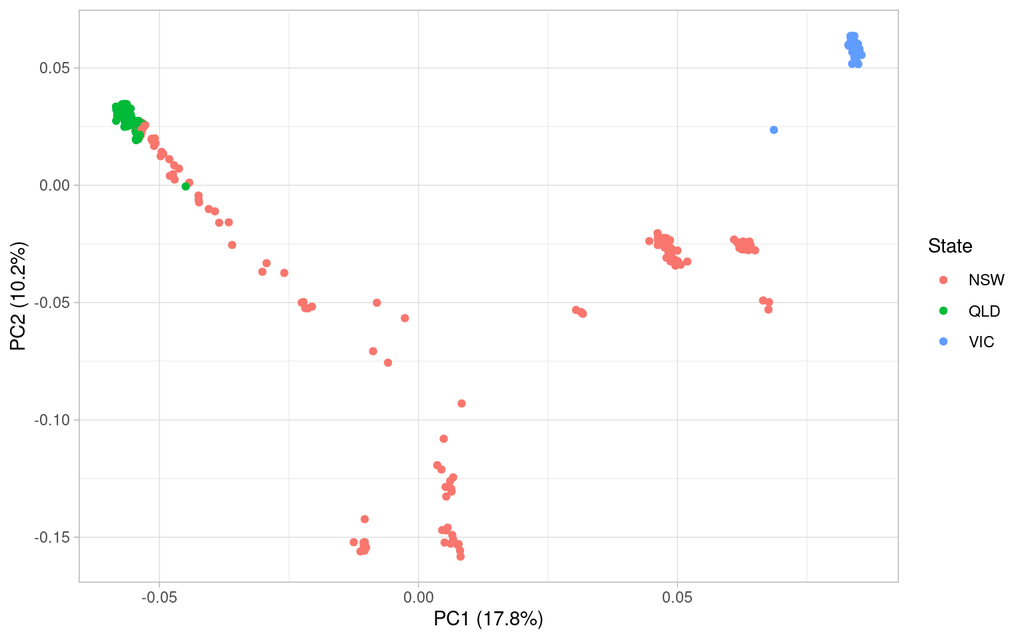

```r
predictors %>%
  ggplot(aes(x = PC1, y = PC2, color = State)) +
  geom_point() +
  theme_light() +
  labs(x = "PC1 (17.8%)", y = "PC2 (10.2%)")
```

## Variable selection: removing correlated climate variables

First, see correlation (Spearman’s) between all climate variables:

[output not shown]

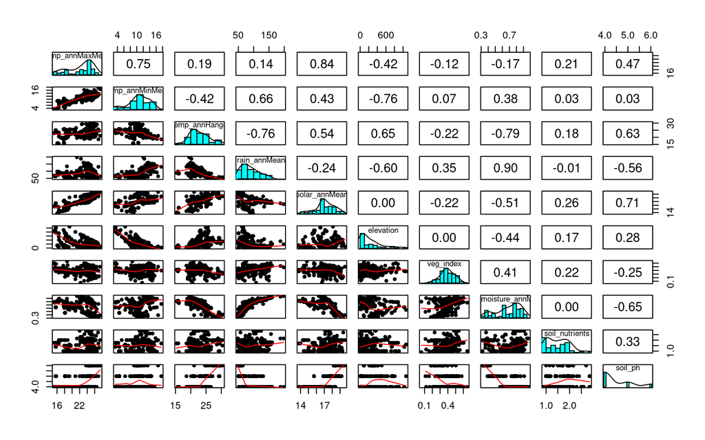

```r
pairs.panels(predictors %>% select(clim_vars), ellipses = F, method = "spearman")
```

Subset “uncorrelated” variables and view again:

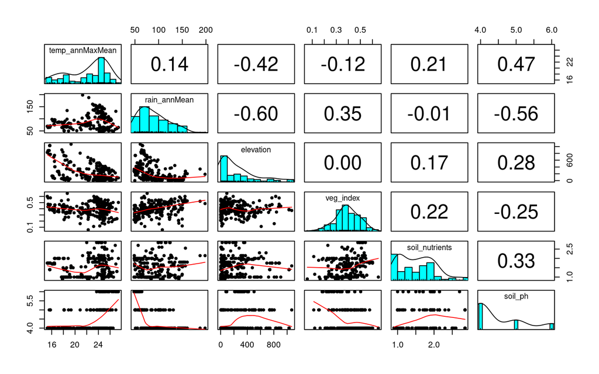

```r
predictors <-
  predictors %>%
  select(-soil_moisture_annMean, -temp_annRange, -solar_annMean, -temp_annMinMean)
clim_vars <- names(predictors)[11:16]

pairs.panels(predictors %>% select(clim_vars), ellipses = F, method = "spearman")
```

## Prepare genotype data (response variables)

Read in SNPs, remove empty/irrelevant columns:

```r
genotype <-
  read.table("~/GitHub/phasco_genes/data/MHC_exons.raw", header = T, row.names = 1) %>%
  select(-c('IID', 'PAT', 'MAT', 'SEX', 'PHENOTYPE'))
genotype <- genotype[!(row.names(genotype) %in% c("M49026_001", "K2")),]

# Ensure genotype and enviro are in the correct order for RDA
genotype <- genotype[order(row.names(genotype)), ]
predictors <- predictors[order(row.names(predictors)), ]
```

Check for missing SNPs. I think `vegan::rda` cannot handle NAs.

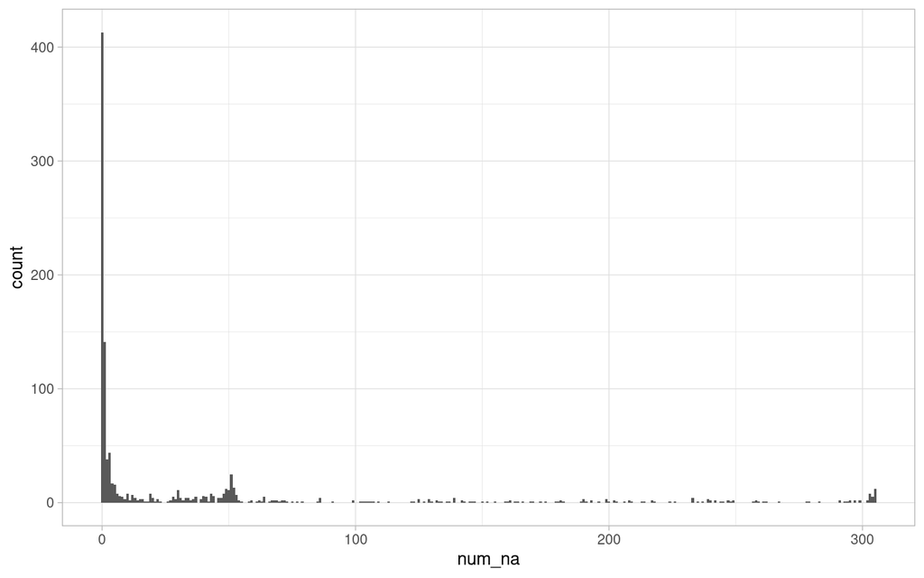

```r
missing_snps <-
  genotype %>%
  summarise(across(everything(), ~ sum(is.na(.)))) %>%
  pivot_longer(cols = everything(), names_to = "locus", values_to = "num_na")

missing_snps %>%
  ggplot(aes(x = num_na)) +
  geom_histogram(binwidth = 1) +
  theme_light()
```

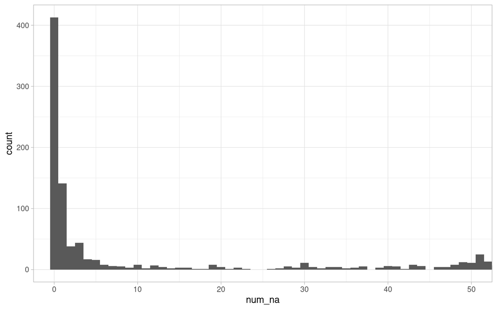

```r
missing_snps %>%
  ggplot(aes(x = num_na)) +
  geom_histogram(binwidth = 1) +
  coord_cartesian(xlim = c(0, 50)) +
  theme_light()
```

413/1083 (38.13%) loci with no NAs. For now, subset and analyse loci with complete data.

```r
complete_loci <-
  missing_snps %>%
  filter(num_na == 0)

genotype_complete <-
  genotype %>%
  select(all_of(complete_loci$locus))
```

## Variance partitioning

Partial RDA (pRDA) quantifies the contribution of different factors on genetic variation. Variables that can be used include genetic population structure, environmental variables, coordinates, etc.

```r
# Model with selected variables, coordinates and states/LGAs
prda_full <- rda(genotype_complete ~ temp_annMaxMean + rain_annMean + elevation + veg_index + soil_nutrients + soil_ph + PC1 + PC2 + PC3 + PC4 + PC5 + PC6, predictors, na.action = na.exclude, scale = T)
r2_full <- RsquareAdj(prda_full)
anova_full <- anova(prda_full)

# Pure climate model
prda_clim <- rda(genotype_complete ~ temp_annMaxMean + rain_annMean + elevation + veg_index + soil_nutrients + soil_ph + Condition(Longitude + Latitude + PC1 + PC2 + PC3 + PC4 + PC5 + PC6), predictors, na.action = na.exclude)
r2_clim <- RsquareAdj(prda_clim)
anova_clim <- anova(prda_clim)

# Pure geography model
prda_geo <- rda(genotype_complete ~ Longitude + Latitude +
                  Condition(temp_annMaxMean + rain_annMean + elevation + veg_index + soil_nutrients + soil_ph + PC1 + PC2 + PC3 + PC4 + PC5 + PC6), predictors, na.action = na.exclude, scale = T)
r2_geo <- RsquareAdj(prda_geo)
anova_geo <- anova(prda_geo)

# Pure structure model
prda_struc <- rda(genotype_complete ~ PC1 + PC2 + PC3 + PC4 + PC5 + PC6 +
                  Condition(temp_annMaxMean + rain_annMean + elevation + veg_index + soil_nutrients + soil_ph), predictors, na.action = na.exclude, scale = T)
r2_struc <- RsquareAdj(prda_struc)
anova_struc <- anova(prda_struc)
```

```r
# Create summary table
`Partial RDA models` <- c("Full model", "Pure climate", "Pure geography", "Pure structure")
Inertia <- c(anova_full$Variance[1], anova_clim$Variance[1], anova_geo$Variance[1], anova_struc$Variance[1])
`Adjusted R^2` <- c(r2_full$adj.r.squared, r2_clim$adj.r.squared, r2_geo$adj.r.squared, r2_struc$adj.r.squared)
`Pr(>F)` <- c(anova_full$`Pr(>F)`[1], anova_clim$`Pr(>F)`[1], anova_geo$`Pr(>F)`[1], anova_struc$`Pr(>F)`[1])

prda_summary <-
  data.frame(`Partial RDA models`, Inertia, `Adjusted R^2`, `Pr(>F)`, check.names = F) %>%
  mutate(Inertia = round(Inertia, 2)) %>%
  mutate(`Adjusted R^2` = round(`Adjusted R^2`, 3)) %>%
  mutate()

rm(prda_full, prda_clim, prda_geo, prda_struc,
   anova_full, anova_clim, anova_geo, anova_struc,
   r2_full, r2_clim, r2_geo, r2_struc)

prda_summary
```

```
##   Partial RDA models Inertia Adjusted R^2 Pr(>F)
## 1         Full model   97.02        0.204  0.001
## 2       Pure climate    2.26        0.010  0.001
## 3     Pure geography    3.03        0.002  0.084
## 4     Pure structure   36.62        0.074  0.001
```

Geography does not significantly explain the variation in SNPs, however, climate and structure do.

## Genotype-Environment Associations: identifying loci under selection

```r
rda_clim <-
  rda(genotype_complete ~ temp_annMaxMean + rain_annMean + elevation + veg_index + soil_nutrients + soil_ph +
        Condition(PC1 + PC2 + PC3 + PC4 + PC5 + PC6), predictors, na.action = na.exclude, scale = T)
rda_clim
```

```
## Call: rda(formula = genotype_complete ~ temp_annMaxMean + rain_annMean
## + elevation + veg_index + soil_nutrients + soil_ph + Condition(PC1 +
## PC2 + PC3 + PC4 + PC5 + PC6), data = predictors, scale = T, na.action =
## na.exclude)
##
##                 Inertia Proportion Rank
## Total         406.00000    1.00000
## Conditional    85.78110    0.21128    6
## Constrained    11.23851    0.02768    6
## Unconstrained 308.98039    0.76104  259
## Inertia is correlations
## 34 observations deleted due to missingness
##
## Eigenvalues for constrained axes:
##  RDA1  RDA2  RDA3  RDA4  RDA5  RDA6
## 3.493 2.883 1.912 1.204 0.976 0.771
##
## Eigenvalues for unconstrained axes:
##    PC1    PC2    PC3    PC4    PC5    PC6    PC7    PC8
## 24.682 20.131 15.031 12.192 11.869 10.335  9.149  8.147
## (Showing 8 of 259 unconstrained eigenvalues)
```

Conditional = structure  
Constrained = climate (RDA axes)  
Unconstrained = PCA axes

```r
r2_rda <- RsquareAdj(rda_clim)
r2_rda
```

```
## $r.squared
## [1] 0.02768106
##
## $adj.r.squared
## [1] 0.01027846
```

In this model, the climate variables explains about 1% of the variation (after accounting for structure).

This low explanatory power may be due to the SNPs analysed are neutral, also possibly because it’s been conditioned with population structure.

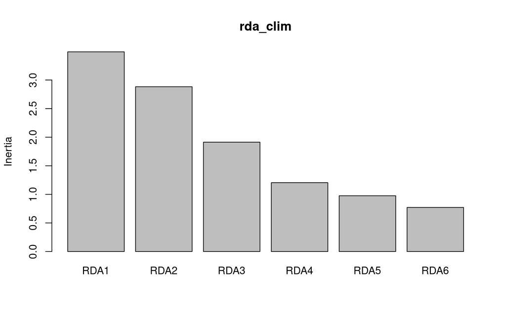

```r
screeplot(rda_clim)
```

```r
anova_rda <- anova.cca(rda_clim, by = "axis")
anova_rda
```

```
## Permutation test for rda under reduced model
## Forward tests for axes
## Permutation: free
## Number of permutations: 999
##
## Model: rda(formula = genotype_complete ~ temp_annMaxMean + rain_annMean + elevation + veg_index + soil_nutrients + soil_ph + Condition(PC1 + PC2 + PC3 + PC4 + PC5 + PC6), data = predictors, scale = T, na.action = na.exclude)
##           Df Variance      F Pr(>F)
## RDA1       1    3.493 2.9279  0.003 **
## RDA2       1    2.883 2.4163  0.004 **
## RDA3       1    1.912 1.6031  0.231
## RDA4       1    1.204 1.0093  0.934
## RDA5       1    0.976 0.8180  0.985
## RDA6       1    0.771 0.6460  0.987
## Residual 259  308.980
## ---
## Signif. codes:  0 '***' 0.001 '**' 0.01 '*' 0.05 '.' 0.1 ' ' 1
```

## Identify putatively adaptive loci

Find outlier SNPs according to the tails of a normal distribution.

https://vitalflux.com/wp-content/uploads/2022/01/z-scores-formula-concepts-and-examples.jpg

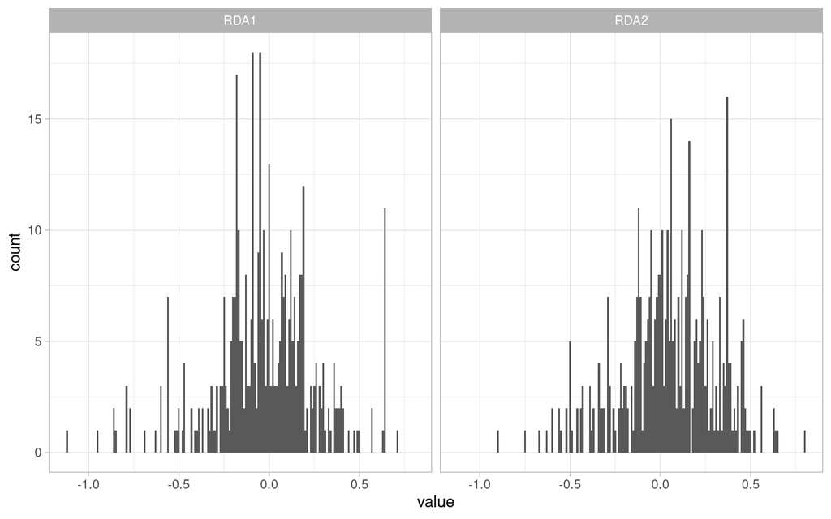

```r
snp_scores <-
  scores(rda_clim, choices = 1:2, display = "species", scaling = 3) %>%
  as.data.frame()

sample_scores <-
  scores(rda_clim, choices = 1:2, display = "sites", scaling = 3) %>%
  as.data.frame() %>%
  mutate(Sample = rownames(.)) %>%
  left_join(predictors %>% mutate(Sample = rownames(.)), by = "Sample")

bp_scores <-
  scores(rda_clim, choices = 1:2, display = "bp", scaling = 3) %>%
  as.data.frame()

snp_scores %>%
  pivot_longer(cols = RDA1:RDA2, names_to = "Axes") %>%
  ggplot(aes(value)) +
  geom_histogram(binwidth = 0.01) +
  facet_wrap(facets = vars(Axes)) +
  theme_light()
```

```r
outlier_snps <- function(snp_scores, rda_axis, z) {
  limits <- mean(snp_scores[,rda_axis]) + c(-1, 1) * z * sd(snp_scores[,rda_axis])
  print(limits)
  x <-snp_scores[snp_scores[rda_axis] < limits[1] | snp_scores[rda_axis] > limits[2], ]
  x %>% mutate(Outlier = paste("RDA", rda_axis, sep = ""))
}

rda1_outs <- outlier_snps(snp_scores, 1, 1.64485)
```

```
## [1] -0.4867927  0.4352387
```

```r
rda2_outs <- outlier_snps(snp_scores, 2, 1.64485)
```

```
## [1] -0.3790751  0.4857800
```

```r
rda_outs <- rbind(rda1_outs, rda2_outs)
rm(rda1_outs, rda2_outs)

rda_outs
```

```
##                                   RDA1        RDA2 Outlier
## MSTS01000255.1.621297_A    -0.49871623 -0.03369987    RDA1
## MSTS01000255.1.989122_C     0.70951159 -0.21685279    RDA1
## MSTS01000255.1.1049352_C   -0.59537132  0.00607050    RDA1
## MSTS01000255.1.1049370_C   -0.59537132  0.00607050    RDA1
## MSTS01000255.1.1052024_C   -0.78965515 -0.11601186    RDA1
## MSTS01000255.1.1052127_G    0.63552754 -0.07872947    RDA1
## MSTS01000255.1.1052131_C    0.63552754 -0.07872947    RDA1
## MSTS01000255.1.1052162_G    0.63552754 -0.07872947    RDA1
## MSTS01000255.1.1052204_T   -0.59537132  0.00607050    RDA1
## MSTS01000255.1.1052735_G   -0.52142902  0.02964737    RDA1
## MSTS01000255.1.1052806_T   -0.78965515 -0.11601186    RDA1
## MSTS01000255.1.1052874_A   -0.78965515 -0.11601186    RDA1
## MSTS01000255.1.1052897_C   -0.84529739 -0.18614045    RDA1
## MSTS01000255.1.1155843_GCT -0.55993902  0.23300593    RDA1
## MSTS01000255.1.1155846_C   -0.55993902  0.23300593    RDA1
## MSTS01000255.1.1155848_G   -0.55993902  0.23300593    RDA1
## MSTS01000255.1.1155849_G   -0.55993902  0.23300593    RDA1
## MSTS01000255.1.1155856_T   -0.55993902  0.23300593    RDA1
## MSTS01000255.1.1155858_T   -0.55993902  0.23300593    RDA1
## MSTS01000255.1.1155861_A   -0.55993902  0.23300593    RDA1
## MSTS01000255.1.1155864_A   -0.85843774 -0.28653975    RDA1
## MSTS01000255.1.1155967_G   -0.85843774 -0.28653975    RDA1
## MSTS01000255.1.1156051_C   -0.51270624  0.46094180    RDA1
## MSTS01000255.1.1175702_T   -0.62946176 -0.44325550    RDA1
## MSTS01000255.1.1175730_T   -1.11661911 -0.07350619    RDA1
## MSTS01000255.1.1177009_A    0.49890064 -0.36782697    RDA1
## MSTS01000255.1.1177016_T    0.49243873 -0.32437168    RDA1
## MSTS01000255.1.1178403_A   -0.76926524 -0.04418946    RDA1
## MSTS01000255.1.1178413_A   -0.76926524 -0.04418946    RDA1
## MSTS01000255.1.1178437_G   -0.69374757 -0.06301371    RDA1
## MSTS01000255.1.1178441_A   -0.94891421 -0.06602755    RDA1
## MSTS01000255.1.1210480_A   -0.49996335 -0.31818135    RDA1
## MSTS01000255.1.1211449_G    0.62925029 -0.11416154    RDA1
## MSTS01000129.1.3856637_T    0.64289002  0.06258848    RDA1
## MSTS01000129.1.3856641_A    0.64289002  0.06258848    RDA1
## MSTS01000129.1.3856649_T    0.64289002  0.06258848    RDA1
## MSTS01000129.1.3856664_C    0.64289002  0.06258848    RDA1
## MSTS01000129.1.3856670_G    0.64289002  0.06258848    RDA1
## MSTS01000129.1.3856686_A    0.64289002  0.06258848    RDA1
```

[output cut: 30 more lines]

```
## MSTS01000255.1.1430205_C   -0.22610459 -0.43743942    RDA2
## MSTS01000129.1.3932547_A   -0.26397080 -0.39335331    RDA2
## MSTS01000129.1.3933067_G   -0.06013073 -0.39412814    RDA2
## MSTS01000129.1.3933079_C   -0.09566442 -0.46096107    RDA2
## MSTS01000129.1.3933092_A   -0.23568985 -0.39486271    RDA2
## MSTS01000129.1.3933101_C   -0.22041432 -0.55125322    RDA2
## MSTS01000129.1.3933110_G   -0.20576580 -0.55685493    RDA2
## MSTS01000129.1.3933124_C   -0.25654308 -0.49059952    RDA2
## MSTS01000129.1.3933126_C   -0.24869004 -0.51572362    RDA2
## MSTS01000129.1.3933135_G   -0.20154260 -0.55914689    RDA2
## MSTS01000129.1.3933139_A   -0.25158693 -0.62583947    RDA2
## MSTS01000129.1.3933140_G   -0.19341412 -0.60232652    RDA2
## MSTS01000129.1.3933144_A   -0.24675655 -0.66903030    RDA2
## MSTS01000129.1.3933147_A   -0.20082740 -0.74727012    RDA2
## MSTS01000129.1.3933164_A   -0.26351065 -0.59738056    RDA2
```

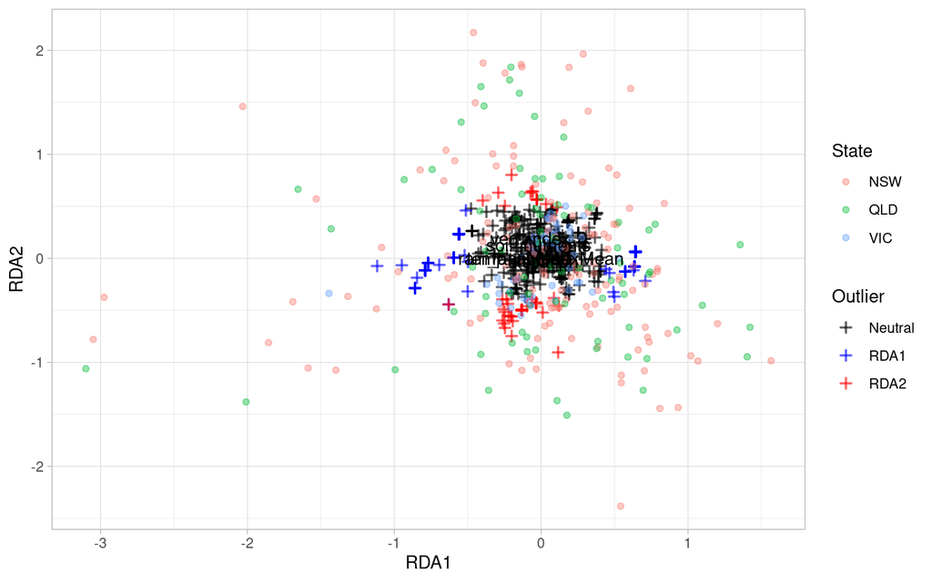

```r
snp_scores_outliers <-
  snp_scores %>%
  add_rownames("Sample") %>%
  left_join(rda_outs, by = c("RDA1", "RDA2")) %>%
  mutate(Outlier = if_else(is.na(Outlier), "Neutral", Outlier))

ggplot() +
  geom_point(data = snp_scores_outliers, aes(RDA1, RDA2, color = Outlier), shape = 3, stroke = 1, alpha = 0.6) +
  scale_color_manual(values = c("black", "blue", "red")) +
  new_scale_color() +
  geom_jitter(data = sample_scores, aes(RDA1, RDA2, color = State), alpha = 0.4) +
  geom_segment(data = bp_scores, aes(xend = RDA1, yend = RDA2, x = 0, y = 0)) +
  geom_text(data = bp_scores, aes(x = RDA1, y = RDA2, label = rownames(bp_scores))) +
  theme_light()
```

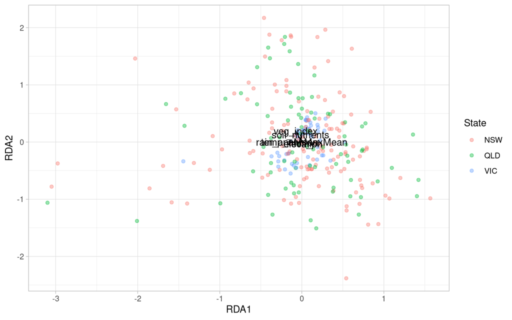

```r
ggplot() +
  geom_jitter(data = sample_scores, aes(RDA1, RDA2, color = State), alpha = 0.4) +
  geom_segment(data = bp_scores, aes(xend = RDA1, yend = RDA2, x = 0, y = 0)) +
  geom_text(data = bp_scores, aes(x = RDA1, y = RDA2, label = rownames(bp_scores))) +
  theme_light()
```

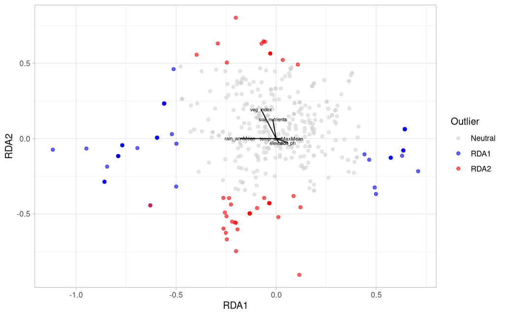

```r
ggplot() +
  geom_point(data = snp_scores_outliers, aes(RDA1, RDA2, color = Outlier), alpha = 0.6) +
  scale_color_manual(values = c("lightgrey", "blue", "red")) +
  geom_segment(data = bp_scores, aes(xend = RDA1, yend = RDA2, x = 0, y = 0)) +
  geom_text(data = bp_scores, aes(x = RDA1, y = RDA2, label = rownames(bp_scores)), size = 2) +
  theme_light()
```